# Práctica - Módulo 3

#### Estimador bisquare

Realizamos una regresión robusta utilizando el método bisquare. Después comprobamos la normalidad.

```r
mod8 = rlm(log(mpg)~weight+year+as.factor(origin),data = datos, psi = psi.bisquare)
summary(mod8)
```

```
##
## Call: rlm(formula = log(mpg) ~ weight + year + as.factor(origin), data = datos,
##     psi = psi.bisquare)
## Residuals:
##      Min       1Q   Median       3Q      Max
## -0.42955 -0.07412  0.00659  0.06514  0.38992
##
## Coefficients:
##                    Value    Std. Error t value
## (Intercept)          1.6673   0.1394    11.9593
## weight              -0.0003   0.0000   -31.8651
## year                 0.0298   0.0017    17.6684
## as.factor(origin)2   0.0567   0.0180     3.1526
## as.factor(origin)3   0.0632   0.0180     3.5126
##
## Residual standard error: 0.1015 on 387 degrees of freedom
```

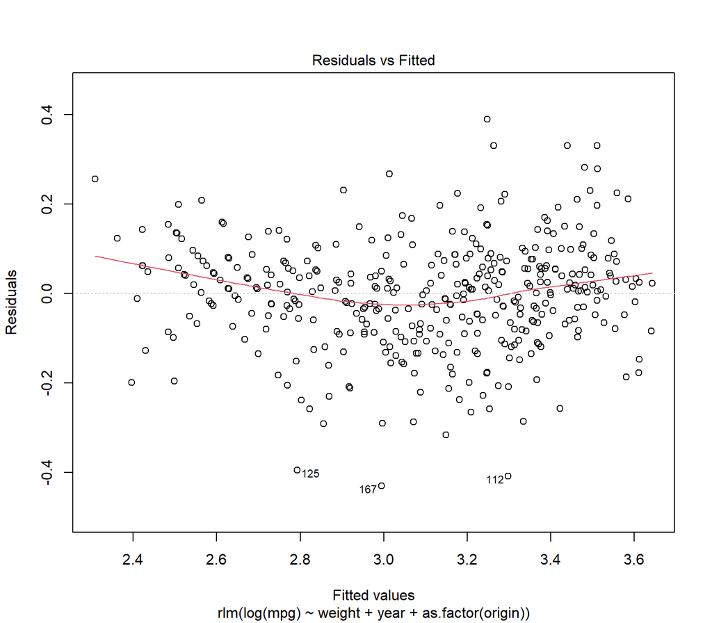

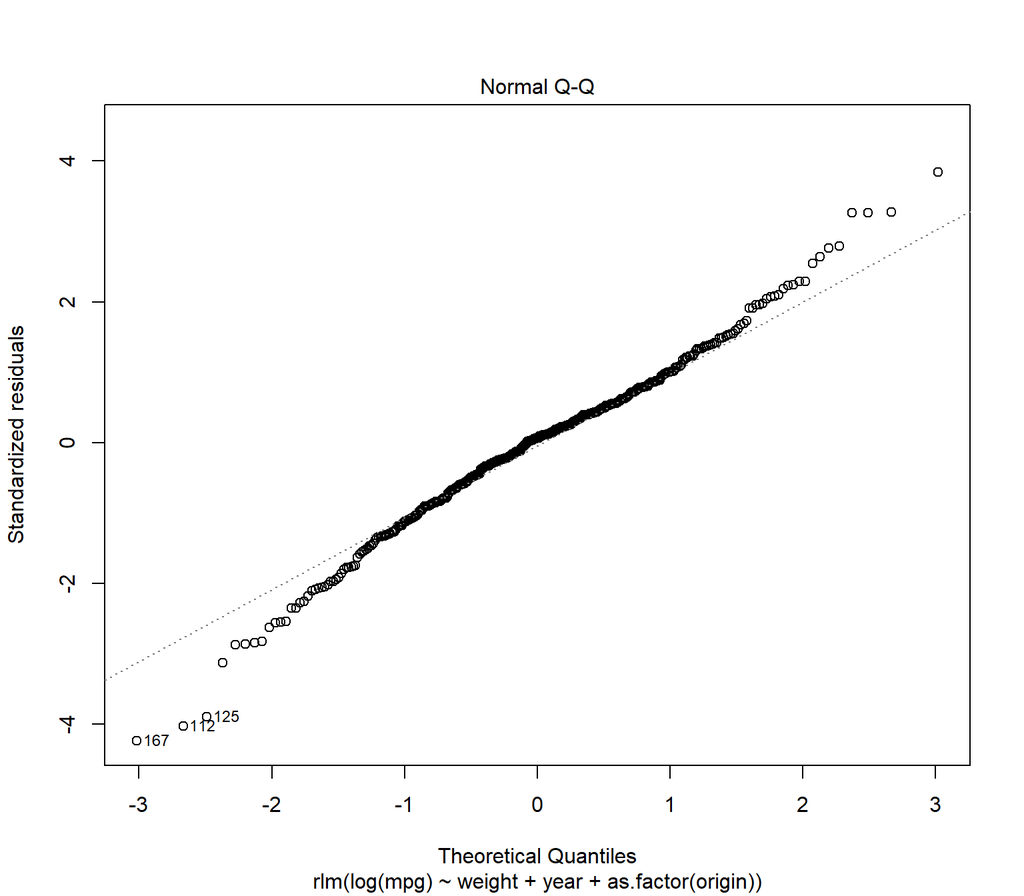

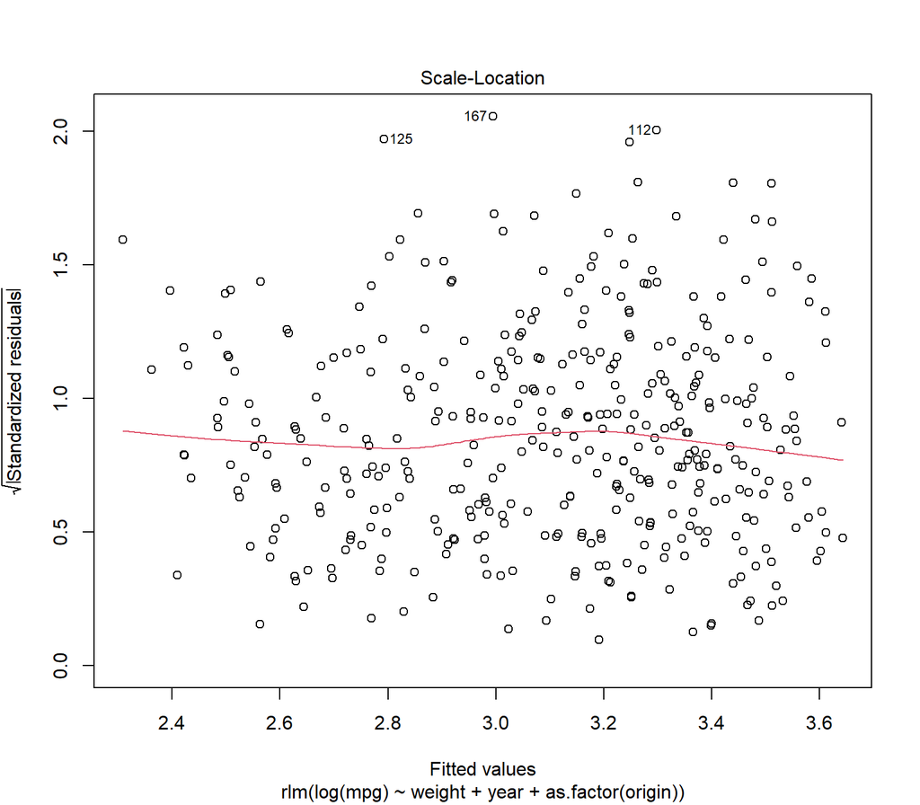

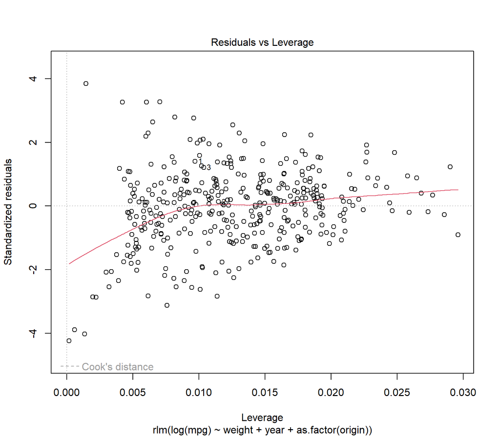

```r
plot(mod8)
```

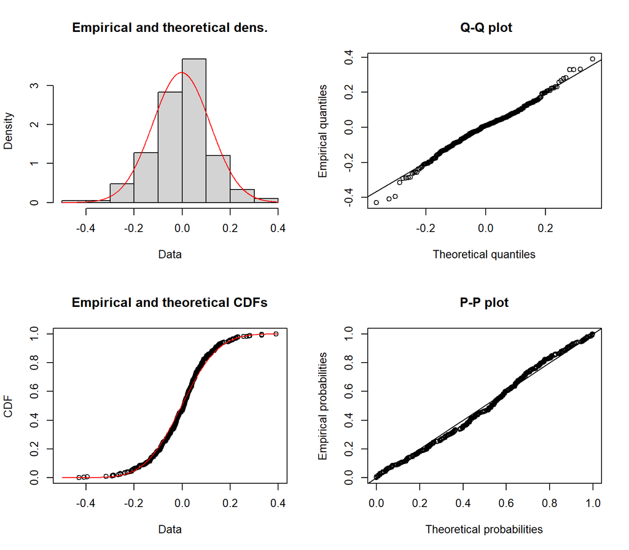

```r
plot(fitdist(mod8$residuals,distr = 'norm'))
```

```r
lillie.test(mod8$residuals)
```

```
##
##  Lilliefors (Kolmogorov-Smirnov) normality test
##
## data:  mod8$residuals
## D = 0.053013, p-value = 0.01016
```

Después de hacer estimaciones robustas con dos métodos (Huber y bisquare), podemos ver que ambos métodos tienen bajo error residual. Ambos métodos dieron resultados similares. Se puede observar que no hay normalidad entre los residuos.

# 9 - Ejercicio 9

Con el mismo modelo, realice una estimación utilizando la regresión bayesiana, y responda razonadamente por cuál de los tres modelos (inicial, robusto, bayesiano) optaría como modelo final.

#### Regresión Bayesiana

Utilizamos la librería MCMCpack para realizar la regresión bayesiana y representamos gráficamente el modelo.

```r
library(MCMCpack)
modeloRB = MCMCregress (log(mpg) ~ weight + year+as.factor(origin), data = datos)
summary(modeloRB)
```

```
##
## Iterations = 1001:11000
## Thinning interval = 1
## Number of chains = 1
## Sample size per chain = 10000
##
## 1. Empirical mean and standard deviation for each variable,
##    plus standard error of the mean:
##
##                          Mean        SD  Naive SE Time-series SE
## (Intercept)         1.5026722 1.452e-01 1.452e-03      1.429e-03
## weight             -0.0002863 9.472e-06 9.472e-08      9.472e-08
## year                0.0319092 1.761e-03 1.761e-05      1.733e-05
## as.factor(origin)2  0.0702952 1.882e-02 1.882e-04      1.929e-04
## as.factor(origin)3  0.0575625 1.876e-02 1.876e-04      1.876e-04
## sigma2              0.0145603 1.059e-03 1.059e-05      1.059e-05
##
## 2. Quantiles for each variable:
##
##                          2.5%        25%        50%        75%      97.5%
## (Intercept)         1.2140411  1.4052310  1.5023912  1.6001803  1.7893775
## weight             -0.0003051 -0.0002927 -0.0002861 -0.0002798 -0.0002679
## year                0.0284249  0.0307207  0.0318981  0.0330790  0.0353824
## as.factor(origin)2  0.0337765  0.0575556  0.0702668  0.0828317  0.1075552
## as.factor(origin)3  0.0201842  0.0449567  0.0575693  0.0698395  0.0953759
## sigma2              0.0126066  0.0138298  0.0145078  0.0152244  0.0168040
```

Aquí, cada fila corresponde a un parámetro, por lo que hay dos gráficos para cada parámetro. El gráfico de la izquierda se denomina trace plot y muestra los valores que tomó el parámetro durante la ejecución de la cadena. El gráfico de la derecha se denomina gráfico de densidad marginal. Básicamente, es el histograma (suavizado) de los valores del trace plot, es decir, la distribución de los valores del parámetro en la cadena. Los trace plot muestran una buena mezcla, lo que indica que más iteraciones no son necesarias para garantizar que la distribución se ha representado con precisión.

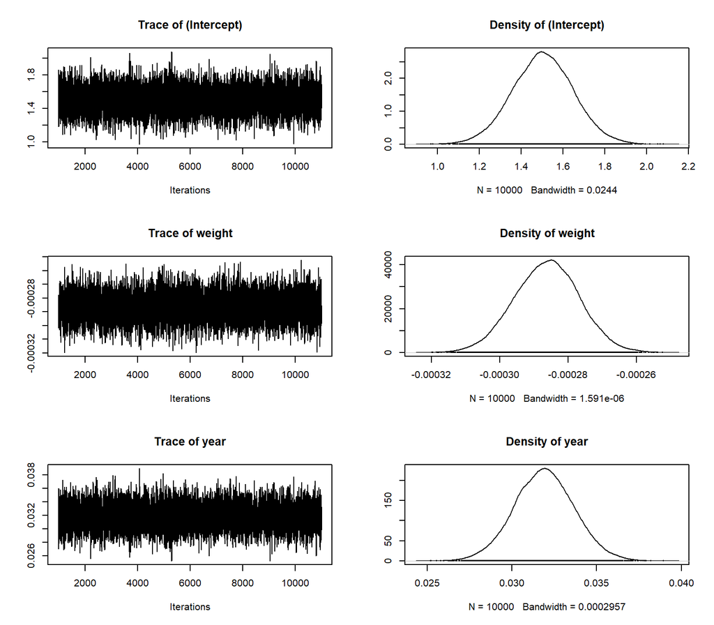

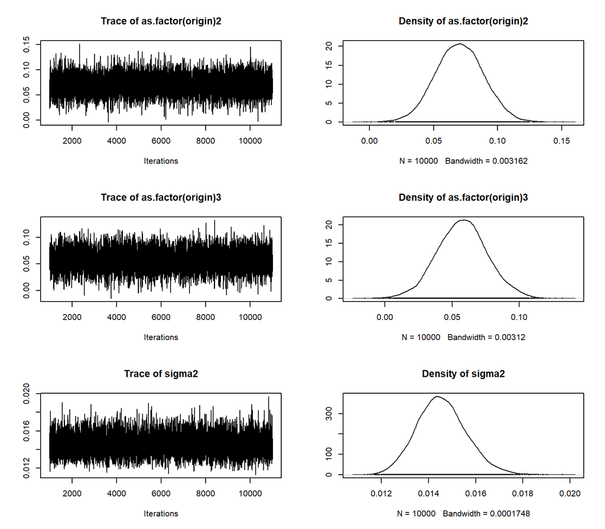

```r
plot(modeloRB)
```

Ahora comparamos algunas métricas de los modelos (inicial, dos de robusto, bayesiano):

- **MCO**

```r
AIC(mod3)
```

```
## [1] -540.9114
```

```r
BIC(mod3)
```

```
## [1] -517.0839
```

```r
# Error residual
sqrt(sum(mod3$residual^2) / mod3$df.residual)
```

```
## [1] 0.1203003
```

- **Regresión robusta Huber**

```r
#AIC
AIC(mod7)
```

```
## [1] -539.4504
```

```r
#BIC
BIC(mod7)
```

```
## [1] -515.6229
```

```r
# Error residual
summary(mod7)["sigma"]
```

```
## $sigma
## [1] 0.1041304
```

- **Regresión robusta bisquare**

```r
#AIC
AIC(mod8)
```

```
## [1] -538.4659
```

```r
#BIC
BIC(mod8)
```

```
## [1] -514.6383
```

```r
# Error residual
summary(mod8)["sigma"]
```

```
## $sigma
## [1] 0.101458
```

- **Bayesiano**

```r
#R-cuadrado
library(broom)
library(broom.mixed)
mcmc <- modeloRB
Xmat = model.matrix(log(mpg) ~ weight + year+as.factor(origin), data = datos)
coefs = mcmc[, c("(Intercept)", "weight", "year", "as.factor(origin)2", "as.factor(origin)3")]
fit = coefs %*% t(Xmat)
resid = sweep(fit, 2, datos$mpg, "-")
var_f = apply(fit, 1, var)
var_e = apply(resid, 1, var)
R2 = var_f/(var_f + var_e)
tidyMCMC(as.mcmc(R2), conf.int = TRUE, conf.method = "HPDinterval")
```

```
## # A tibble: 1 × 5
##   term  estimate std.error conf.low conf.high
##   <chr>    <dbl>     <dbl>    <dbl>     <dbl>
## 1 var1   0.00179 0.0000716  0.00165   0.00193
```

```r
# Error residual Bayesiano
sqrt(mean(modeloRB[,6]))
```

```
## [1] 0.1206663
```

Observamos los cuatro modelos anteriores y concluimos:

En las estimaciones robustas, los errores residuales son bajos, pero los modelos no muestran signos de normalidad entre sus residuos, por lo que no pueden considerarse aptos para predecir el mpg.

Ahora si comparamos el modelo bayesiano (modeloRB) con el modelo MCO (mod3), el error residual de ambos modelos es prácticamente el mismo. La R cuadrada estimada del modelo Bayesiano es muy pequeña, lo que indica que los predictores del modelo no explican una gran proporción de la varianza en la variable de respuesta (mpg). Por lo tanto, el modelo bayesiano no es una buena opción para predecir el consumo (mpg) de un coche.

El mod3(MCO) muestra normalidad entre los residuos y también tiene homocedasticidad y no muestra alta multicolinealidad. Se comporta mejor que otros modelos, ya que explica el 87,61% de la varianza en la determinación del consumo (mpg) de combustible de un coche. Por lo tanto, yo elegiría **mod3 (MCO)** para predecir mpg.

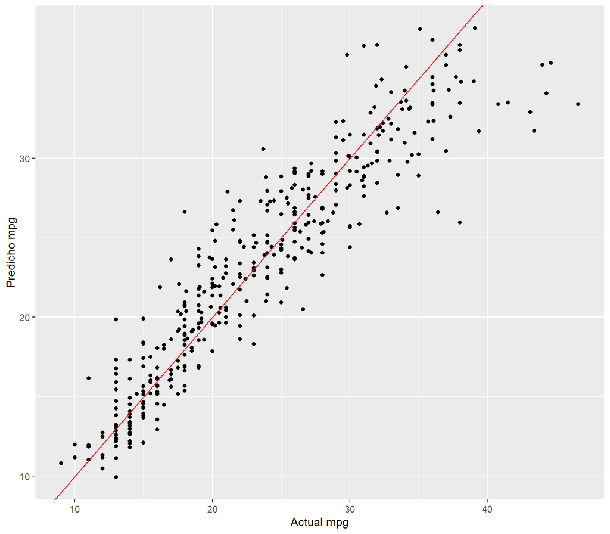

```r
pred <- exp(predict(mod3))

library(ggplot2)
ggplot(data = datos,aes(x = datos$mpg, y = pred)) +
  geom_point() +
  geom_abline(intercept = 0, slope = 1, color = "red") +
  labs(x = "Actual mpg", y = "Predicho mpg")
```

# 10 - Ejercicio 10

Realice una estimación no lineal entre el consumo de gasolina, en millas por galón (mpg_i), y los caballos de vapor del vehiculo (horsepower_i). Utilice bases polinómicas y splines. Encuentre el mejor modelo con ambas tecnicas, y compare sus resultados.

#### **Ajustes Polinómicos**

En primer lugar, vamos a representar los datos originales.

Observamos que no se trata de una línea recta, por lo que podemos continuar con los ajustes polinómicos.

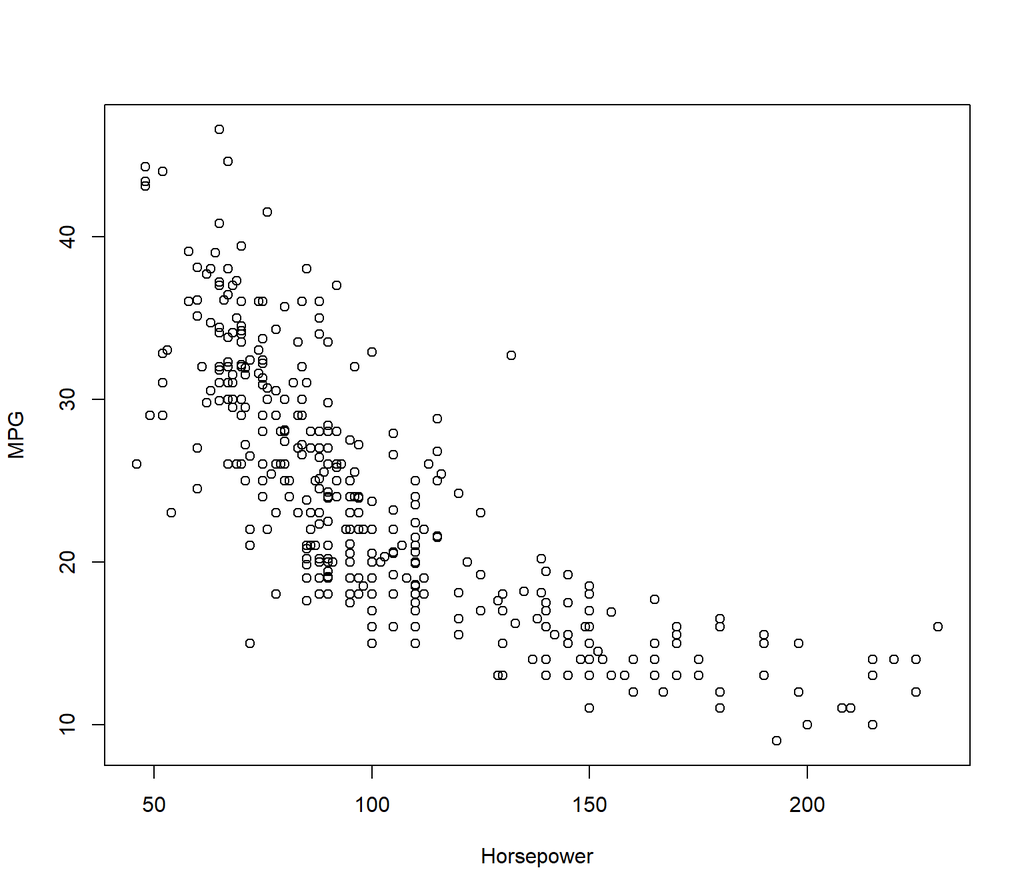

```r
plot(datos$horsepower, datos$mpg, xlab = "Horsepower", ylab = "MPG")
```

```r
modelo2 <- lm(formula = mpg ~ poly(horsepower, 2),datos)
summary(modelo2)
```

```
##
## Call:
## lm(formula = mpg ~ poly(horsepower, 2), data = datos)
##
## Residuals:
##      Min       1Q   Median       3Q      Max
## -14.7135  -2.5943  -0.0859   2.2868  15.8961
##
## Coefficients:
##                       Estimate Std. Error t value Pr(>|t|)
## (Intercept)            23.4459     0.2209  106.13   <2e-16 ***
## poly(horsepower, 2)1 -120.1377     4.3739  -27.47   <2e-16 ***
## poly(horsepower, 2)2   44.0895     4.3739   10.08   <2e-16 ***
## ---
## Signif. codes:  0 '***' 0.001 '**' 0.01 '*' 0.05 '.' 0.1 ' ' 1
##
## Residual standard error: 4.374 on 389 degrees of freedom
## Multiple R-squared:  0.6876, Adjusted R-squared:  0.686
## F-statistic:   428 on 2 and 389 DF,  p-value: < 2.2e-16
```

```r
modelo3 <- lm(formula = mpg ~ poly(horsepower, 3),datos)
summary(modelo3)
```

```
##
## Call:
## lm(formula = mpg ~ poly(horsepower, 3), data = datos)
##
## Residuals:
##      Min       1Q   Median       3Q      Max
## -14.7039  -2.4491  -0.1519   2.2035  15.8159
##
## Coefficients:
##                      Estimate Std. Error t value Pr(>|t|)
## (Intercept)            23.446      0.221 106.105   <2e-16 ***
## poly(horsepower, 3)1 -120.138      4.375 -27.460   <2e-16 ***
## poly(horsepower, 3)2   44.090      4.375  10.078   <2e-16 ***
## poly(horsepower, 3)3   -3.949      4.375  -0.903    0.367
## ---
## Signif. codes:  0 '***' 0.001 '**' 0.01 '*' 0.05 '.' 0.1 ' ' 1
##
## Residual standard error: 4.375 on 388 degrees of freedom
## Multiple R-squared:  0.6882, Adjusted R-squared:  0.6858
## F-statistic: 285.5 on 3 and 388 DF,  p-value: < 2.2e-16
```

```r
modelo4 <- lm(formula = mpg ~ poly(horsepower, 4),datos)
summary(modelo4)
```

```
##
## Call:
## lm(formula = mpg ~ poly(horsepower, 4), data = datos)
##
## Residuals:
##      Min       1Q   Median       3Q      Max
## -14.8820  -2.5802  -0.1682   2.2100  16.1434
##
## Coefficients:
##                       Estimate Std. Error t value Pr(>|t|)
## (Intercept)            23.4459     0.2209 106.161   <2e-16 ***
## poly(horsepower, 4)1 -120.1377     4.3727 -27.475   <2e-16 ***
## poly(horsepower, 4)2   44.0895     4.3727  10.083   <2e-16 ***
## poly(horsepower, 4)3   -3.9488     4.3727  -0.903    0.367
## poly(horsepower, 4)4   -5.1878     4.3727  -1.186    0.236
## ---
## Signif. codes:  0 '***' 0.001 '**' 0.01 '*' 0.05 '.' 0.1 ' ' 1
##
## Residual standard error: 4.373 on 387 degrees of freedom
## Multiple R-squared:  0.6893, Adjusted R-squared:  0.6861
## F-statistic: 214.7 on 4 and 387 DF,  p-value: < 2.2e-16
```

```r
anova(modelo2, modelo3, modelo4)
```

```
## Analysis of Variance Table
##
## Model 1: mpg ~ poly(horsepower, 2)
## Model 2: mpg ~ poly(horsepower, 3)
## Model 3: mpg ~ poly(horsepower, 4)
##   Res.Df    RSS Df Sum of Sq      F Pr(>F)
## 1    389 7442.0
## 2    388 7426.4  1    15.593 0.8155 0.3670
## 3    387 7399.5  1    26.913 1.4076 0.2362
```

Seleccionamos el modelo2 porque todos los factores son significativos.

Ahora lo representamos frente a los valores originales.

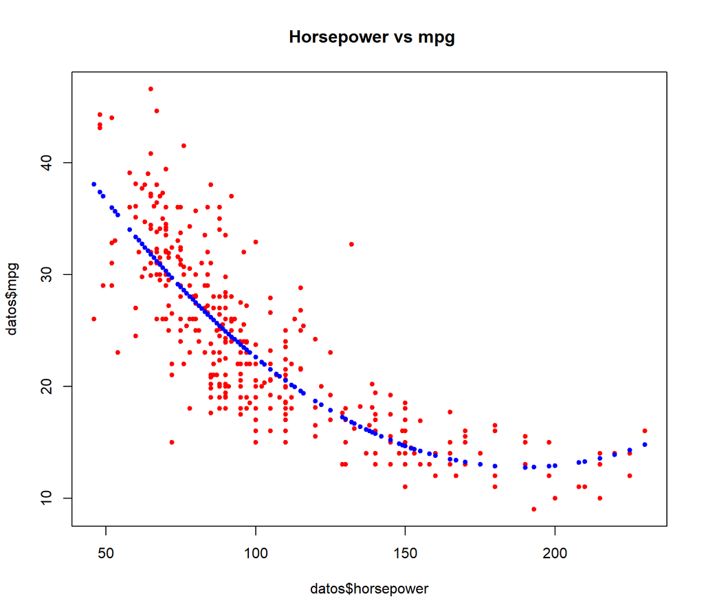

```r
plot(x=datos$horsepower, y=datos$mpg, main=" Horsepower vs mpg", pch=20, col = "red")
points(datos$horsepower, fitted(modelo2), col='blue', pch=20)
```

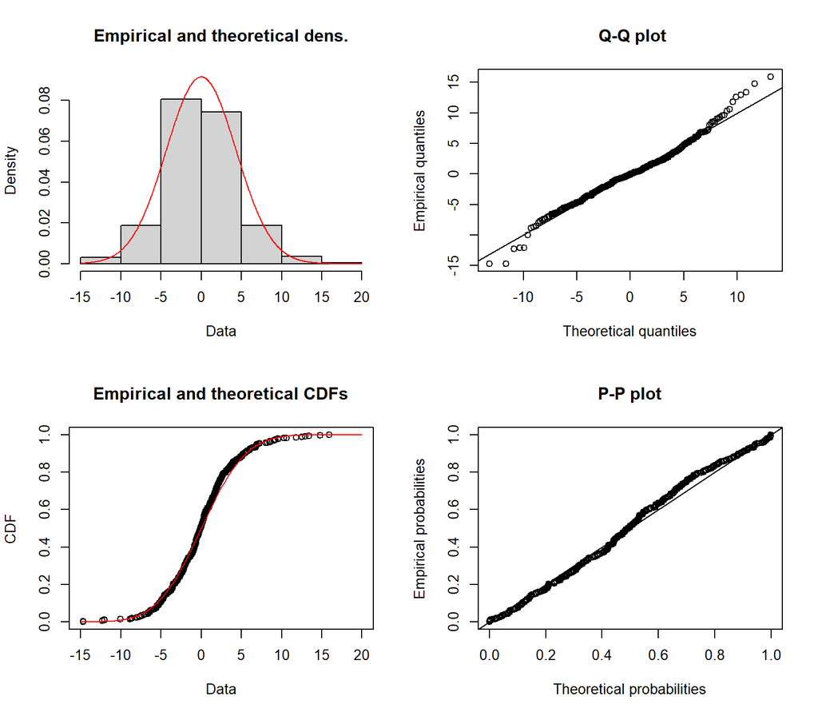

```r
plot(fitdist(modelo2$residuals,distr = 'norm'))
```

```r
lillie.test(modelo2$residuals)
```

```
##
##  Lilliefors (Kolmogorov-Smirnov) normality test
##
## data:  modelo2$residuals
## D = 0.058508, p-value = 0.002611
```

Podemos observar que el modelo anterior no muestra signos de normalidad. Se puede confirmar leyendo los gráficos e interpretando los resultados de la prueba de Lillie.

#### **Splines**

Para ello utilizamos la librería splines

1. **Spline cúbica**

Para ello utilizamos la función bs().

```r
library(splines)

modspline <- lm(mpg ~ bs(horsepower,knots=c(100,150,200),degree=3),data=datos)
summary(modspline)
```

```
##
## Call:
## lm(formula = mpg ~ bs(horsepower, knots = c(100, 150, 200), degree = 3),
##     data = datos)
##
## Residuals:
##      Min       1Q   Median       3Q      Max
## -15.5067  -2.5560  -0.2547   2.0828  15.7581
##
## Coefficients:
##                                                        Estimate Std. Error
## (Intercept)                                            35.19166    1.51528
## bs(horsepower, knots = c(100, 150, 200), degree = 3)1   0.08649    2.41819
## bs(horsepower, knots = c(100, 150, 200), degree = 3)2 -17.23214    1.55475
## bs(horsepower, knots = c(100, 150, 200), degree = 3)3 -18.72593    2.30929
## bs(horsepower, knots = c(100, 150, 200), degree = 3)4 -24.41980    2.68399
## bs(horsepower, knots = c(100, 150, 200), degree = 3)5 -22.90991    3.53771
## bs(horsepower, knots = c(100, 150, 200), degree = 3)6 -19.99751    3.64129
##                                                       t value Pr(>|t|)
## (Intercept)                                            23.224  < 2e-16 ***
## bs(horsepower, knots = c(100, 150, 200), degree = 3)1   0.036    0.971
## bs(horsepower, knots = c(100, 150, 200), degree = 3)2 -11.084  < 2e-16 ***
## bs(horsepower, knots = c(100, 150, 200), degree = 3)3  -8.109 6.89e-15 ***
## bs(horsepower, knots = c(100, 150, 200), degree = 3)4  -9.098  < 2e-16 ***
## bs(horsepower, knots = c(100, 150, 200), degree = 3)5  -6.476 2.88e-10 ***
## bs(horsepower, knots = c(100, 150, 200), degree = 3)6  -5.492 7.24e-08 ***
## ---
## Signif. codes:  0 '***' 0.001 '**' 0.01 '*' 0.05 '.' 0.1 ' ' 1
##
## Residual standard error: 4.331 on 385 degrees of freedom
## Multiple R-squared:  0.6968, Adjusted R-squared:  0.6921
## F-statistic: 147.5 on 6 and 385 DF,  p-value: < 2.2e-16
```

```r
rango <- range(datos$horsepower)
npuntos <- seq(from = rango[1], to = rango[2], by = 0.5)
npuntos <- data.frame(horsepower = npuntos)
npredic  <- predict(modspline, newdata = npuntos, se.fit = TRUE, level = 0.95)
```

```r
intconf <- data.frame(
                  inferior = npredic$fit - 1.96*npredic$se.fit,
                  superior = npredic$fit + 1.96*npredic$se.fit)
```

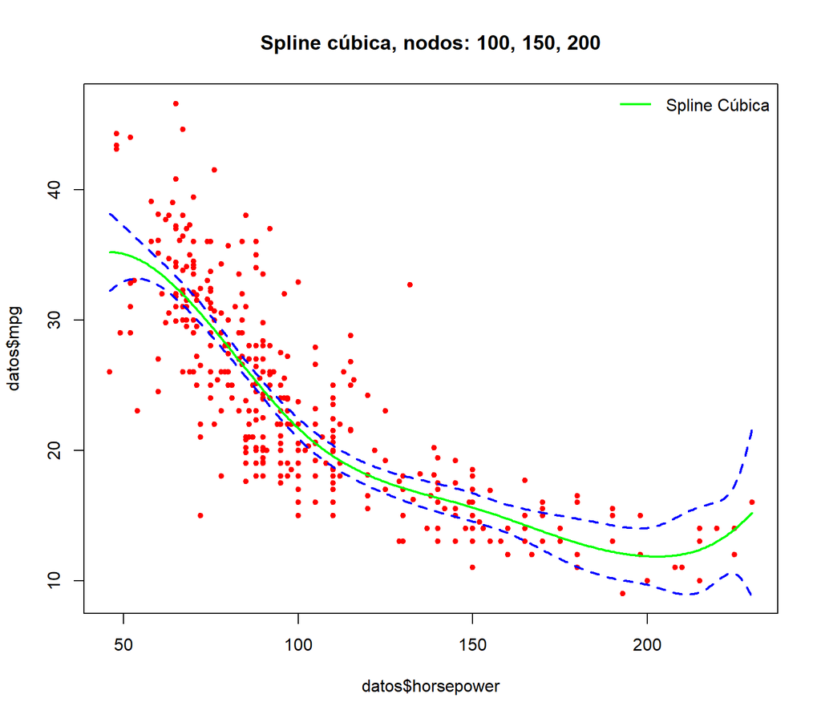

```r
plot(x = datos$horsepower, y =datos$mpg, pch = 20, col = "red")
title("Spline cúbica, nodos: 100, 150, 200")
lines(x = npuntos$horsepower, npredic$fit, col = "green", lwd = 2)
lines(x = npuntos$horsepower, intconf$inferior, col = "blue",
      lwd = 2, lty = 2)
lines(x = npuntos$horsepower, intconf$superior, col = "blue",
      lwd = 2, lty = 2)
legend("topright",
       legend = c("Spline Cúbica")
                  ,
       col = c("green"),
       lwd = 2,
       bty = "n")
```

Podemos observar que no existe normalidad entre los residuos.

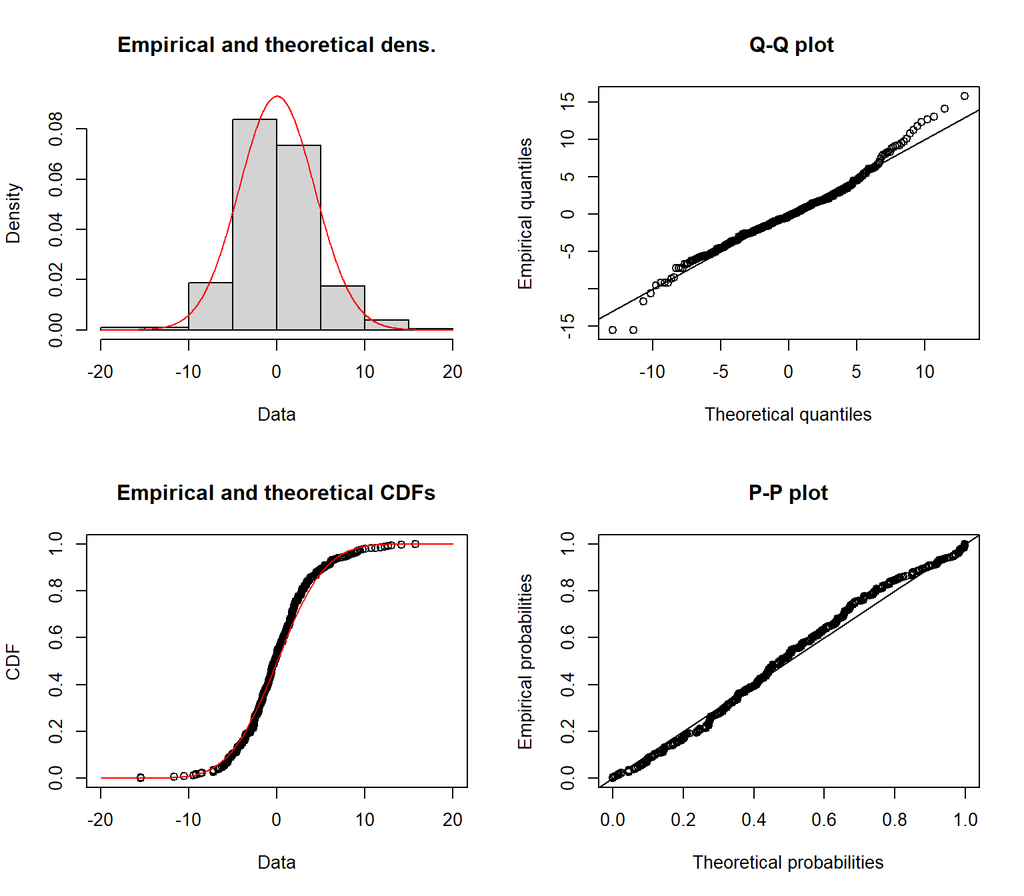

```r
plot(fitdist(modspline$residuals,distr = 'norm'))
```

```r
lillie.test(modspline$residuals)
```

```
##
##  Lilliefors (Kolmogorov-Smirnov) normality test
##
## data:  modspline$residuals
## D = 0.066447, p-value = 0.0002734
```

2. **Spline Natural**

Para ello utilizamos la función ns().

```r
modspline2 <- lm(mpg ~ ns(horsepower, knots=c(100,150,200)),data=datos)
summary(modspline2)
```

```
##
## Call:
## lm(formula = mpg ~ ns(horsepower, knots = c(100, 150, 200)),
##     data = datos)
##
## Residuals:
##      Min       1Q   Median       3Q      Max
## -14.8497  -2.5859  -0.2182   2.2983  15.6661
##
## Coefficients:
##                                           Estimate Std. Error t value Pr(>|t|)
## (Intercept)                                38.5435     0.8612   44.76  < 2e-16
## ns(horsepower, knots = c(100, 150, 200))1 -23.5865     1.1905  -19.81  < 2e-16
## ns(horsepower, knots = c(100, 150, 200))2 -22.7269     2.0541  -11.06  < 2e-16
## ns(horsepower, knots = c(100, 150, 200))3 -40.4877     2.4750  -16.36  < 2e-16
## ns(horsepower, knots = c(100, 150, 200))4 -13.8236     2.1333   -6.48  2.8e-10
##
## (Intercept)                               ***
## ns(horsepower, knots = c(100, 150, 200))1 ***
## ns(horsepower, knots = c(100, 150, 200))2 ***
## ns(horsepower, knots = c(100, 150, 200))3 ***
## ns(horsepower, knots = c(100, 150, 200))4 ***
## ---
## Signif. codes:  0 '***' 0.001 '**' 0.01 '*' 0.05 '.' 0.1 ' ' 1
##
## Residual standard error: 4.361 on 387 degrees of freedom
## Multiple R-squared:  0.691,  Adjusted R-squared:  0.6878
## F-statistic: 216.3 on 4 and 387 DF,  p-value: < 2.2e-16
```

```r
rango2 <- range(datos$horsepower)
npuntos2 <- seq(from = rango2[1], to = rango2[2], by = 0.5)
npuntos2 <- data.frame(horsepower = npuntos2)

npredic2  <- predict(modspline2, newdata = npuntos2, se.fit = TRUE, level = 0.95)
```

```r
intconf2 <- data.frame(
                  inferior = npredic2$fit - 1.96*npredic2$se.fit,
                  superior = npredic2$fit + 1.96*npredic2$se.fit)
```

Representación conjunta de ambas splines.

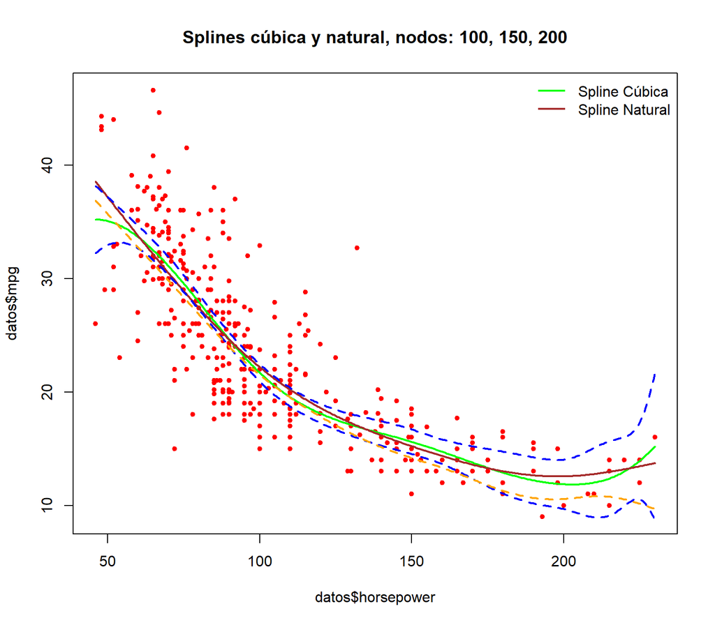

```r
plot(x = datos$horsepower, y =datos$mpg, pch = 20, col = "red")
title("Splines cúbica y natural, nodos: 100, 150, 200")
lines(x = npuntos$horsepower, npredic$fit, col = "green", lwd = 2)
lines(x = npuntos2$horsepower, npredic2$fit, col = "brown", lwd = 2)
lines(x = npuntos$horsepower, intconf$inferior, col = "blue",
      lwd = 2, lty = 2)
lines(x = npuntos$horsepower, intconf$superior, col = "blue",
      lwd = 2, lty = 2)
lines(x = npuntos2$horsepower, intconf2$inferior, col = "orange",
      lwd = 2, lty = 2)
legend("topright",
       legend = c("Spline Cúbica",
                  "Spline Natural"),
       col = c("green", "brown"),
       lwd = 2,
       bty = "n")
```

En el gráfico anterior podemos ver cómo el spline natural (marrón) se hace un poco más plano hacia el final. También podemos observar que no existe normalidad entre los residuos.

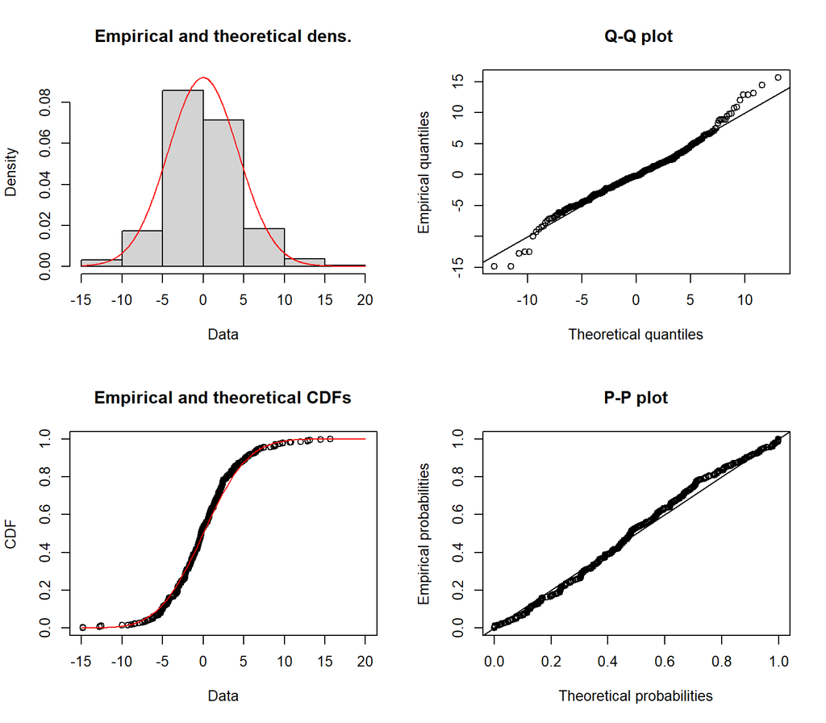

```r
plot(fitdist(modspline2$residuals,distr = 'norm'))
```

```r
lillie.test(modspline2$residuals)
```

```
##
##  Lilliefors (Kolmogorov-Smirnov) normality test
##
## data:  modspline2$residuals
## D = 0.065425, p-value = 0.0003727
```

3. **Smooth Splines**

Para obtenerlo, utilizamos smooth.spline()

```r
modspline3 <- smooth.spline(datos$horsepower, datos$mpg)
modspline3$spar
```

```
## [1] 0.2648644
```

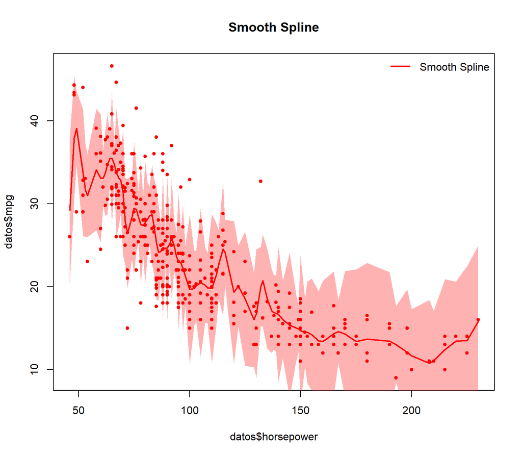

```r
plot(x = datos$horsepower, y =datos$mpg, pch = 20, col = "red")
title("Smooth Spline")
lines(modspline3, col = "red", lwd = 2)
legend("topright",
       legend = c("Smooth Spline"),
                         col = c("red"),
       lwd = 2,
       bty = "n")
```

Vemos que con el valor de **0.2648644**, la curva es muy ondulada.

Cuando la curva es ondulada y no suave, significaría que está capturando el patrón demasiado de cerca y, por lo tanto, podría resultar en un sobreajuste (overfitting) que no es deseable en un modelo.

Probamos con un valor de spar más bajo

4. Ajustamos con un spar de **0,10.**

```r
modspline4 <- smooth.spline(datos$horsepower, datos$mpg,spar=0.10)
modspline4$spar
```

```
## [1] 0.1
```

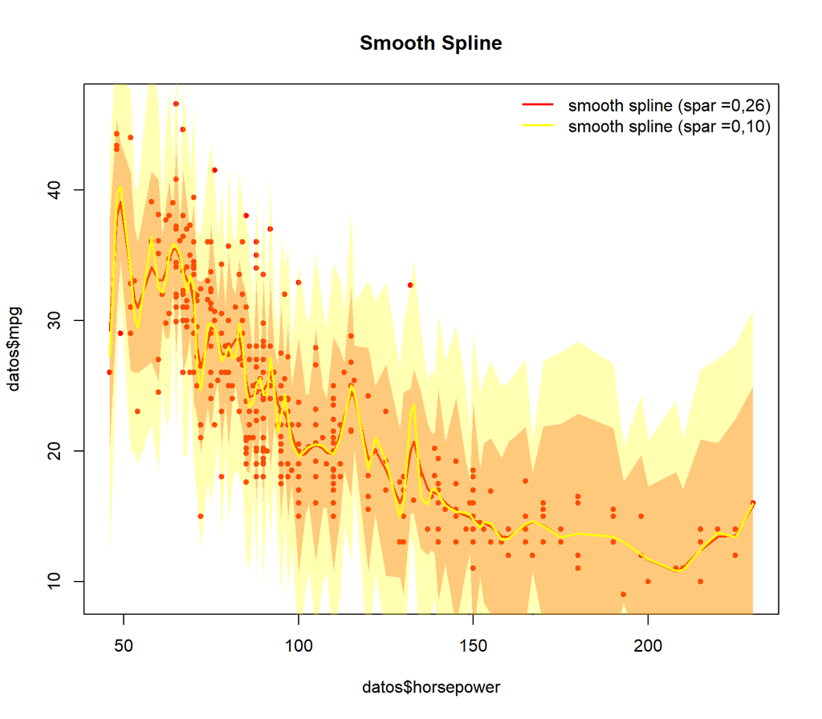

```r
plot(x = datos$horsepower, y =datos$mpg, pch = 20, col = "red")
title("Smooth Spline")
lines(modspline3, col = "red", lwd = 2)
lines(modspline4, col = "yellow", lwd = 2)
legend("topright",
       legend = c("smooth spline (spar =0,26)",
                  "smooth spline (spar =0,10)"),
       col = c("red", "yellow"),
       lwd = 2,
       bty = "n")
```

La reducción del valor de spar hace que la curva se vuelva aún más ondulada. Se confirma que necesitamos un valor de spar por encima de 0,26 para obtener una curva suave.

**Smooth spline, con spar ajustado**

5. Probamos ahora con el valor de spar ajustado: **0,65**.

```r
modspline5 <- smooth.spline(datos$horsepower, datos$mpg,spar=0.65)
modspline5$df
```

```
## [1] 11.76264
```

```r
modspline5$lambda
```

```
## [1] 0.0003090007
```

```r
modspline5$spar
```

```
## [1] 0.65
```

Ahora la curva se ve más suave y perfecta.

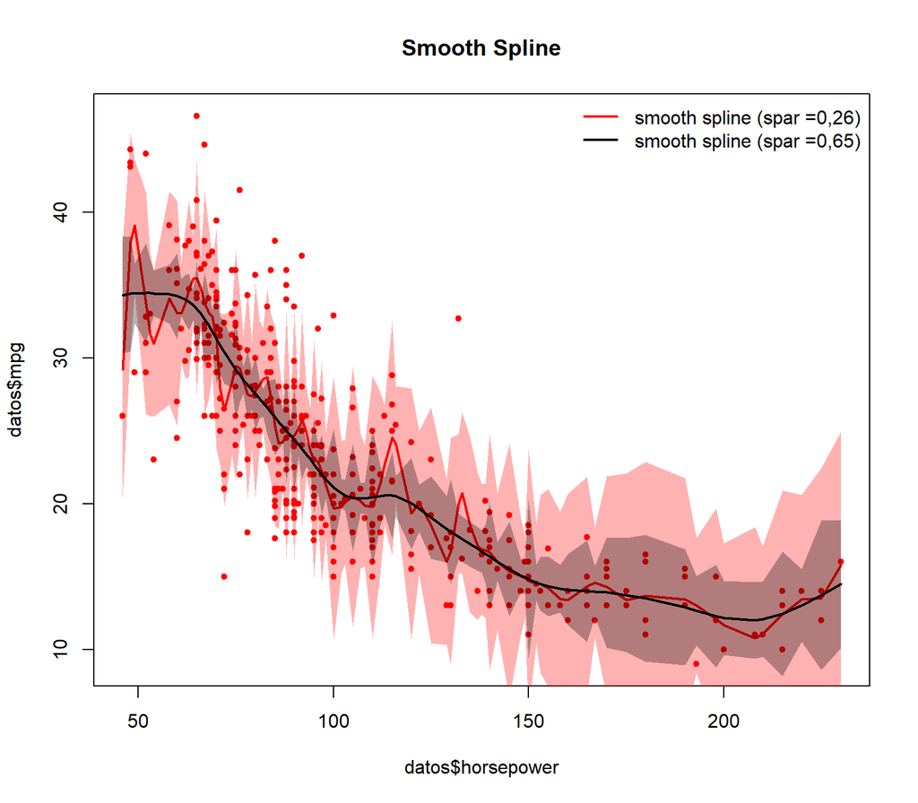

```r
plot(x = datos$horsepower, y =datos$mpg, pch = 20, col = "red")
title("Smooth Spline")
lines(modspline3, col = "red", lwd = 2)
lines(modspline5, col = "black", lwd = 2)
legend("topright",
       legend = c("smooth spline (spar =0,26)",
                  "smooth spline (spar =0,65)"),
       col = c("red", "black"),
       lwd = 2,
       bty = "n")
```

Como la curva se ve bien, probamos la normalidad y calculamos el R-cuadrado y el error residual para comparación.

```r
y <- datos$mpg
yhat <- predict(modspline5, datos$horsepower)$y
SSres <- sum((y - yhat)^2)
SStot <- sum((y - mean(y))^2)
rsq <- 1 - (SSres / SStot)

rmse <- sqrt(mean((y - yhat)^2))

cat("R-cuadrado:", round(rsq, 3), "\n")
```

```
## R-cuadrado: 0.71
```

```r
cat("Error_residual:", round(rmse, 3), "\n")
```

```
## Error_residual: 4.201
```

Observamos que no hay normalidad entre los residuos.

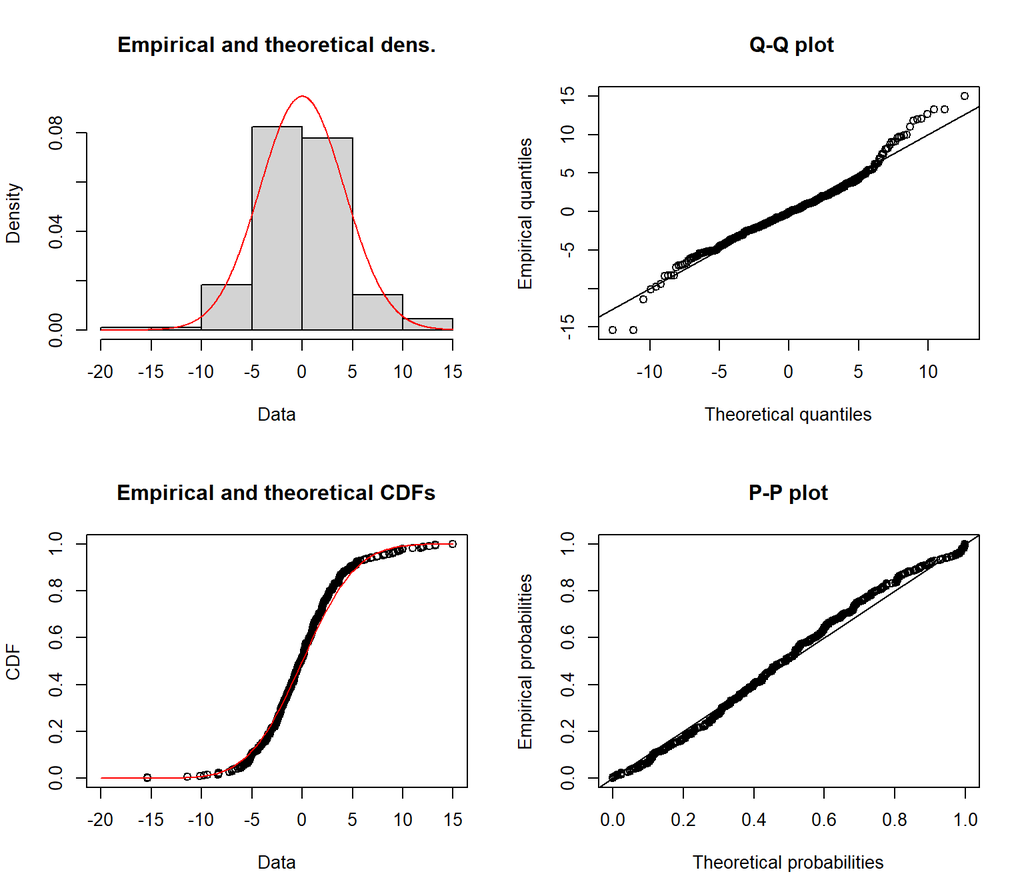

```r
plot(fitdist(y - yhat,distr = 'norm'))
```

```r
lillie.test(y - yhat)
```

```
##
##  Lilliefors (Kolmogorov-Smirnov) normality test
##
## data:  y - yhat
## D = 0.057649, p-value = 0.003264
```

**Gráfico de puntos y todos los splines ajustados**

Finalmente se dibujan los puntos originales con todos los modelos ajustados (cúbico,natural,smooth(spar= 0,26, 0,10 y 0,65))

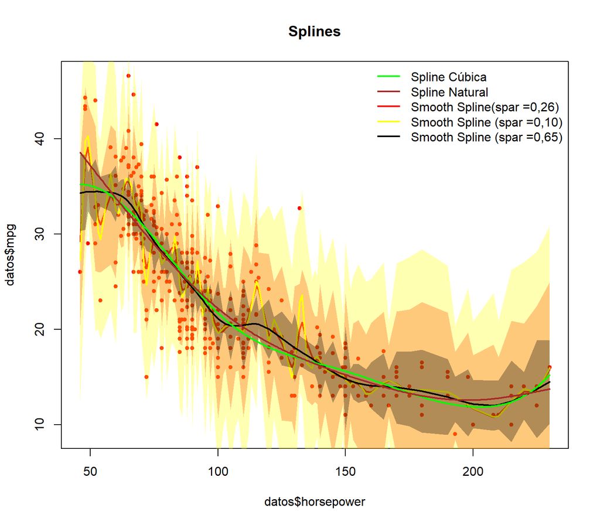

```r
plot(x = datos$horsepower, y =datos$mpg, pch = 20, col = "red")
title("Splines")
lines(modspline3, col = "red", lwd = 2)
lines(modspline4, col = "yellow", lwd = 2)
lines(modspline5, col = "black", lwd = 2)
lines(x = npuntos$horsepower, npredic$fit, col = "green", lwd = 2)
lines(x = npuntos2$horsepower, npredic2$fit, col = "brown", lwd = 2)
legend("topright",
       legend = c("Spline Cúbica",
                  "Spline Natural",
                  "Smooth Spline(spar =0,26) ",
                  "Smooth Spline (spar =0,10)",
                  "Smooth Spline (spar =0,65)"),
       col = c("green", "brown", "red", "yellow", "black"),
       lwd = 2,
       bty = "n")
```

#### Resumen: Regresiones polinomial y splines

Representamos los residuos de los cuatro modelos juntos. Observamos que todos los modelos dan resultados similares. No hay homocedasticidad entre los residuos.

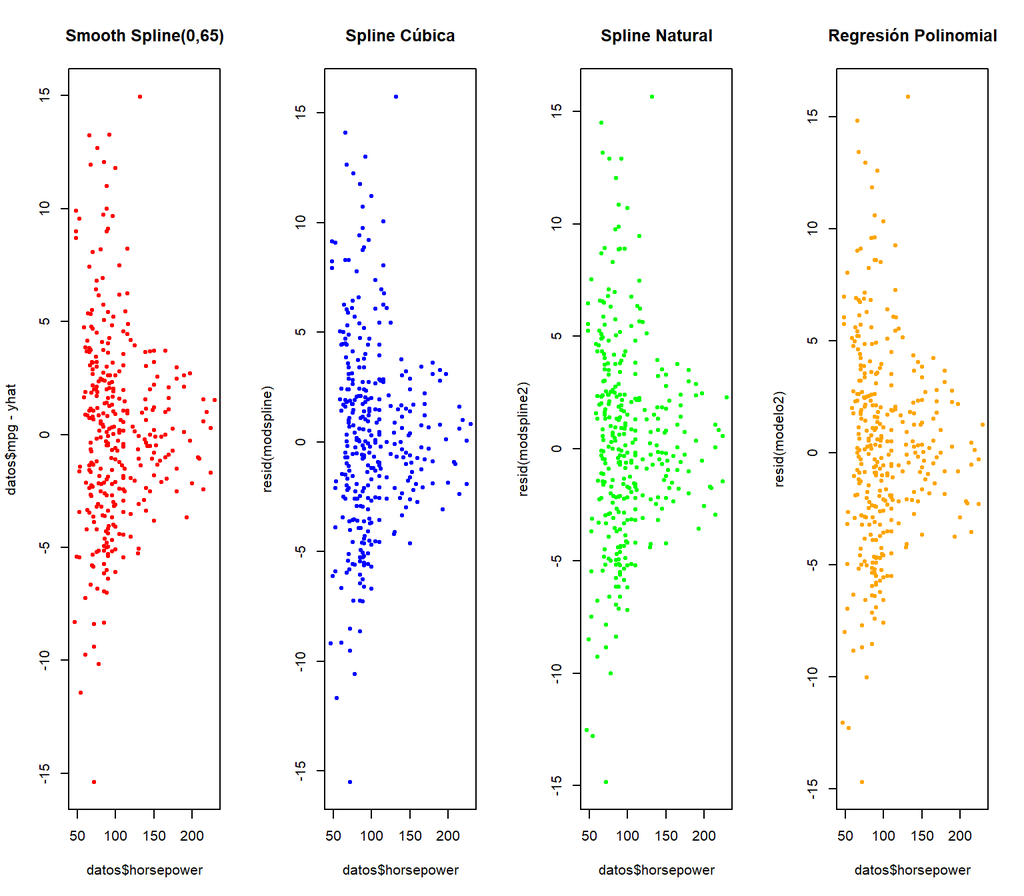

```r
par(mfrow = c(1, 4))
plot(datos$horsepower, datos$mpg - yhat, pch = 20, col = "red", main = "Smooth Spline(0,65)")
plot(datos$horsepower, resid(modspline), pch = 20, col = "blue", main = "Spline Cúbica")
plot(datos$horsepower, resid(modspline2), pch = 20, col = "green", main = "Spline Natural")
plot(datos$horsepower, resid(modelo2), pch = 20, col = "orange", main = "Regresión Polinomial")
```

```r
resuelto <- data.frame(Model = c("Polinomial", "Spline Cúbica", "Spline Natural","Smooth Spline"),
                             R_cuadrado = c(summary(modelo2)$r.squared, summary(modspline)$r.squared, summary(modspline2)$r.squared,round(rsq, 3)),

                             Error_residual = c("4.373",  "4.331", "4.361","4.201")
)

print(resuelto)
```

```
##            Model R_cuadrado Error_residual
## 1     Polinomial  0.6875590          4.373
## 2  Spline Cúbica  0.6968448          4.331
## 3 Spline Natural  0.6909693          4.361
## 4  Smooth Spline  0.7100000          4.201
```

Hemos ajustado mpg en función de horsepower. Hemos hecho regresiones no lineales utilizando bases polinómicas y spline. Realizamos regresiones spline utilizando métodos cúbico, natural y smooth.

En la tabla anterior podemos comparar los valores de error residual y R-cuadrado de los cuatro modelos. Podemos ver que la regresión polinomial no nos da un buen ajuste en comparación con splines. La regresión polinomial da un valor de R-cuadrado más pequeño y el error residual más alto. Esto se puede entender ya que la regresión polinomial ajusta todo el conjunto de datos mediante una sola función polinomial, mientras que la regresión spline ajusta diferentes secciones del conjunto de datos mediante múltiples polinomios por partes (splines).

Por otro lado, las splines cúbica y natural dan resultados similares y también muestran un buen ajuste. Pero el mejor ajuste parece ser con la smooth spline con un valor de R-cuadrado de 0,71, lo que indica que explica el 71 % de la varianza en la determinación de mpg. También su error residual (4,201) es el menor entre los cuatro modelos.

Ninguno de los modelos anteriores (no lineales) muestran signos de normalidad. El **smooth spline** en general parece ajustarse mejor entre todos ellos, tal y como se puede confirmar con la gráfica también.

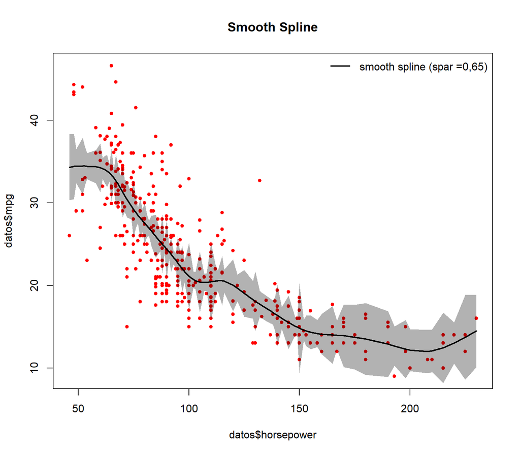

```r
plot(x = datos$horsepower, y =datos$mpg, pch = 20, col = "red")
title("Smooth Spline")
lines(modspline5, col = "black", lwd = 2)
legend("topright",
       legend = c("smooth spline (spar =0,65)"),
       col = c("black"),
       lwd = 2,
       bty = "n")
```